# Shrinking body size in Atlantic Forest birds as a response to climate change

Eduardo S.A. Santos

João C.T. Menezes

Gustavo Burin

11 June, 2026

# Introduction

Guidelines[^1]

Two of the main responses of organisms to climate change are phenological changes and geographical range shifts (Parmesan and Yohe 2003). Yet, a third response of organisms to global warming is increasingly being observed, the shrinkage of bodies (Teplitsky and Millien 2014; Sheridan and Bickford 2011; Gardner et al. 2011). Body shrinkage due to climate change has been hypothesized to be a consequence of ecological or evolutionary processes (Ozgul et al. 2009). The ecological hypothesis posits that climate change influences trophic interactions, thus leading to a reduction in body size. Here we show that Atlantic Forest passerine birds decreased in body size over the last 28 years. The body size shrinkage is associated with both an increase in temperatures over the period as well as a large reduction in the abundance of invertebrates that serve as food resource to passerine birds. Our findings thus highlight the rapid and widespread consequences of climatic change on the availability of prey items, consequently influencing the phenotype of avian predators.

Changes in temperature can result in temperature-dependent or -independent mechanisms that influece body size (reviewed in Gardner et al. 2011). Among temperature-independent mechanisms, decreases in food availability caused by habitat loss or fragmentation may lead to the reduction of body size (Schmidt and Jensen 2005). Thus, limiting juveniles access to resources could lead to smaller adult body size (Teplitsky et al. 2008; Rode et al. 2010). Reductions in body size have been attributed to genetic microevolutionary responses to warming; smaller individuals dissipate heat better than larger individuals due to the larger ratio between surface:volume of their bodies (e.g., Bergmann’s rule, Teplitsky and Millien 2014).[^2]

> Paragraph to talk about the main finding of this study in relation to body size and climate change. For *Nature Climate Change* remember to combine results and some methods so that readers understand what you did.

# Methods

## Pipeline switches

The document knits top-to-bottom with no manual chunk running. By **default** it is fast and reproducible: heavy Bayesian models are *not* re-fit at knit — instead the pre-computed objects from `atlantic_parallel.R` (wing), `atlantic_parallel_bill.R` (bill), and the arthropod fit chunks are loaded and summarised. Flip a switch below to `TRUE` to regenerate that piece during the knit (slower; needs the extra packages).

## Load libraries

```r
library("tidyverse")    # dplyr/ggplot2/tibble (provides %>%) used throughout
library("ggthemes")
library("brms")         # also re-exports as_draws_df(), hypothesis()
library("lme4")
library("ape")
library("geiger")
library("MCMCglmm")
library("mice")
library("tidybayes")
library("reshape2")
library("data.table")
library("metafor")
if (REFRESH_PREDICTS) library("predictsr")   # only needed when refreshing PREDICTS
```

## Load data

This chunk loads the primary dataset for the analysis. The `birds` dataframe is created by reading the `ATLANTIC_BIRD_TRAITS_completed_2018_11_d05.csv` file. This dataset contains morphological measurements and other data for Atlantic Forest birds.

```r
birds <- read_csv("ATLANTIC_BIRD_TRAITS_completed_2018_11_d05.csv", guess_max = 70000)
```

This chunk loads the Elton Traits dataset, which provides functional trait data for birds, including diet information. The `elton` dataframe is created by reading the `BirdFuncDat.txt` file.

```r
elton <- read_tsv("BirdFuncDat.txt")
```

## Data wrangling and new variables

This chunk performs the main data wrangling and cleaning operations. It filters the `birds` dataset to include only adult passerine birds recorded after 1990 within the Atlantic Forest. New variables are created, including a consolidated wing length, scaled year and latitude, and cleaned species names. The data is then filtered to include only species with at least 30 records and a temporal range of at least 5 years. Finally, it selects the relevant columns, adds diet information from the Elton Traits dataset, and saves the cleaned data to `passer90.rda`.

```r
passer90 <- birds %>%
          filter(Year >= 1990, Age == "Adult", Sex != "Unknown", Order == "Passeriformes", AtlanticForests_20km_Buffer == "inside the 20 km polygon") %>%
          mutate(
            conc.wing.length = coalesce(Wing_length_right.mm., Wing_length_left.mm., Wing_length.mm.), # combining all wing lengths to minimize number of NAs in dataset
            ln_conc_wing_length = log(conc.wing.length),
            ln_wing_length = log(Wing_length_right.mm.),
            scaled_lat = scale(Latitude_decimal_degrees*-1),
            scaled_yr = scale(Year),
            Binomial = gsub(" ", "_", Binomial),
            # NOTE: the six manual species-name remaps that used to live here
            # (Ceratopipra_rubrocapilla -> Pipra_rubrocapilla, etc.) targeted the
            # OLD BirdTree/Jetz taxonomy and have been REMOVED. Species names are
            # now reconciled to the (eBird-based) clootl tree by prepR4pcm's
            # reconcile_tree() in the phylo chunk, which handles synonymy/typos
            # in an auditable way. The historical mappings are kept as an
            # override scaffold there in case reconcile flags any of them.
            spp = Binomial # Creating variable for phylo matrix in model later
          ) %>%
          group_by(Binomial) %>%
          filter(n() >= 30) %>% # keeping only spp that have at least 30 records
            mutate(
                  min = min(Year),
                  max = max(Year),
                  range = max-min
                        ) %>%
            filter(range >= 5) # keeping only spp that range at least 5 yrs

# keeping only variables that I will use in the models:
passer90 <- passer90 %>%
              dplyr::select(spp, Binomial, Sex, Year, scaled_yr, Annual_mean_temperature, Latitude_decimal_degrees, scaled_lat, Longitude_decimal_degrees, Wing_length_right.mm.,ln_wing_length,conc.wing.length,ln_conc_wing_length,Bill_width.mm.)

passer90 <- as.data.frame(passer90)

# Inserting diet into passer90 dataframe:
elton$Scientific = gsub(" ", "_", elton$Scientific)
passer90$Diet <- elton$`Diet-5Cat`[match(passer90$spp, elton$Scientific)]

passer90$scaled_lat <- as.numeric(passer90$scaled_lat)
passer90$scaled_yr <- as.numeric(passer90$scaled_yr)

save(passer90, file = "passer90.rda")

saveRDS(
  list(
    n_spp           = dplyr::n_distinct(passer90$Binomial),
    n_rec           = nrow(passer90),
    yr_min          = min(passer90$Year, na.rm = TRUE),
    yr_max          = max(passer90$Year, na.rm = TRUE),
    threshold_min_n = 30L,
    threshold_min_range = 5L
  ),
  "data_summary.rds"
)

rm(birds)
```

Checking the range of years per species in the *passer90* dataframe. Creating a new data frame that contains one entry per species in order to prune the phylogeny later.

```r
load("passer90.rda")

by_binomial <- group_by(passer90, Binomial)
year_range <- summarise(by_binomial,
                  min = min(Year),
                  max = max(Year),
                  range = max-min
                        )

year_range <- as.data.frame(year_range)
row.names(year_range) <- year_range$Binomial # having rows named with the species name is required for any PCM
```

Plots of the range of years per species[^3].

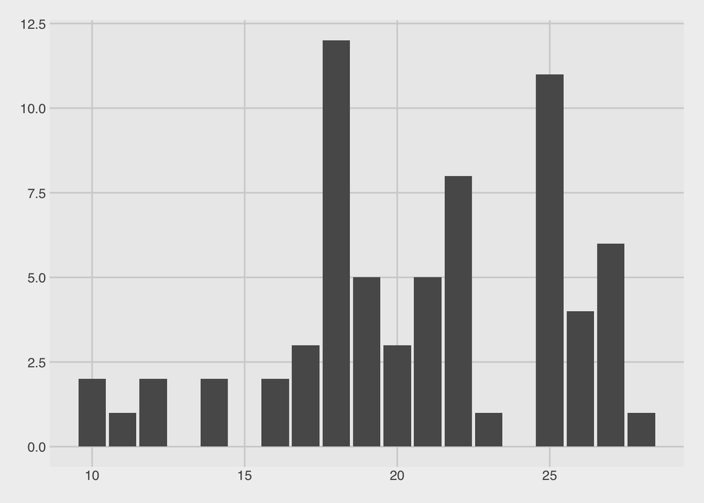

```r
g_year_range <- ggplot(data = year_range, aes(x = range)) +
                  geom_bar() +
                  theme_fivethirtyeight()

g_year_range
```

```r
summary(year_range$range)
```

```
##    Min. 1st Qu.  Median    Mean 3rd Qu.    Max.
##   10.00   18.00   21.00   20.74   25.00   28.00
```

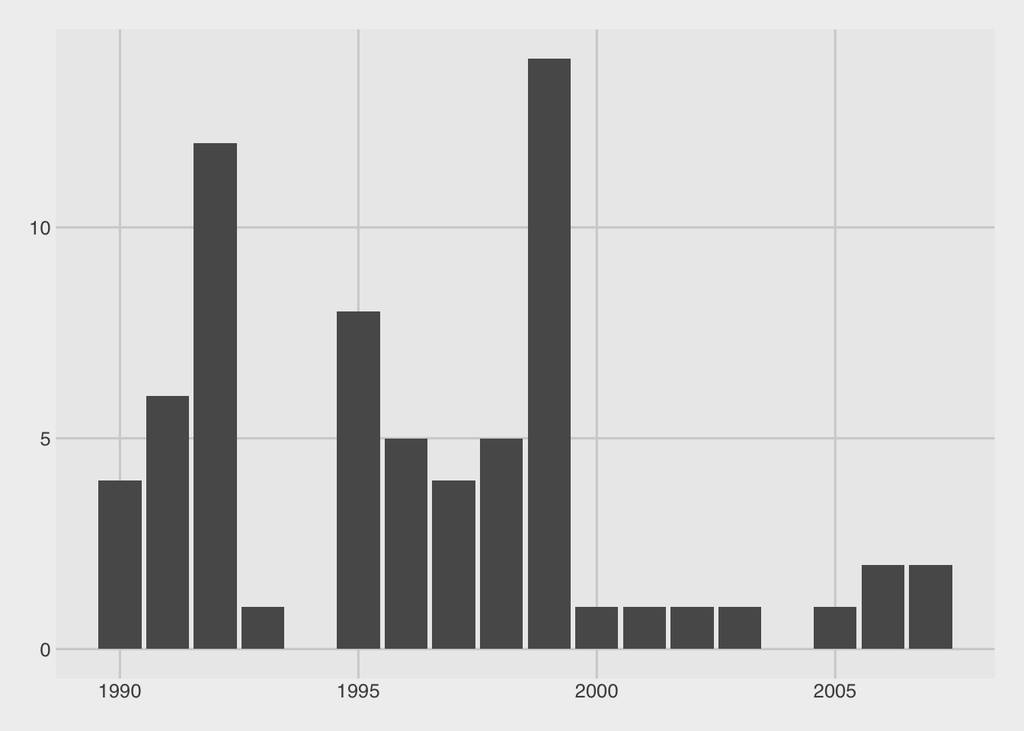

```r
g_year_min <- ggplot(data = year_range, aes(x = min)) +
                  geom_bar() +
                  theme_fivethirtyeight()
g_year_min
```

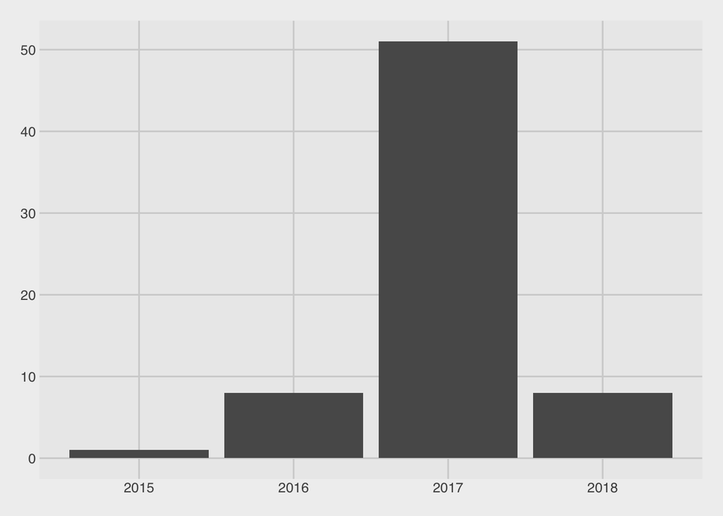

```r
g_year_max <- ggplot(data = year_range, aes(x = max)) +
                  geom_bar() +
                  theme_fivethirtyeight()
g_year_max
```

## Exploratory plots

Plotting some relationships:

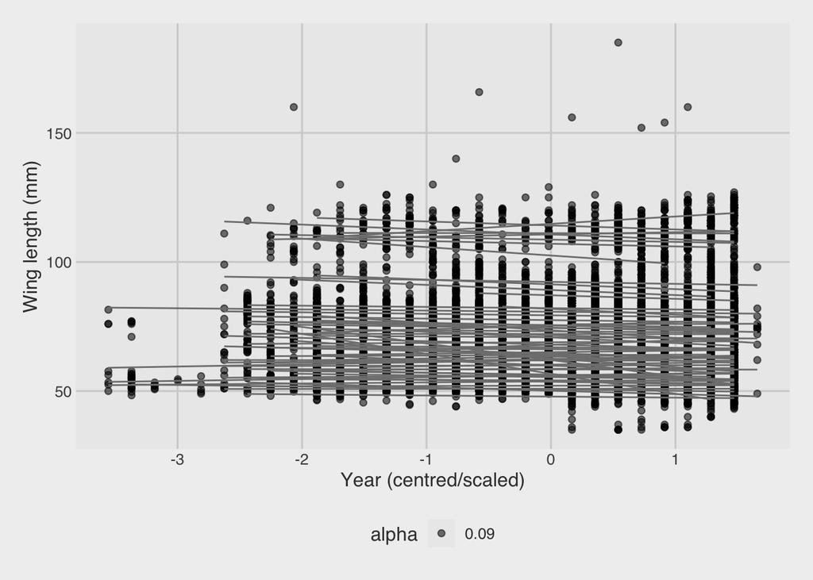

```r
g_wingl <- ggplot(data = passer90, aes(x = scaled_yr, y = conc.wing.length, group = Binomial)) +
  geom_point(aes(alpha = 0.09)) +
  stat_smooth(method = "lm", se = FALSE, colour = "grey50", linewidth = 0.5, alpha = 0.1) + # FIX: size= is deprecated for lines in ggplot2 >= 3.4; use linewidth=
  theme_fivethirtyeight() +
  theme(axis.title = element_text()) +
  ylab("Wing length (mm)") +
  xlab("Year (centred/scaled)")

g_wingl
```

[figure not shown]

```r
pl <- ggplot(passer90, aes(x=Year,y=conc.wing.length))
pl2 <- pl + geom_hex()
print(pl2 +
        scale_fill_gradient(high = "red", low = "blue")  +
        theme_fivethirtyeight() +
        theme(axis.title = element_text()) +
        ylab("Wing length (mm)") +
        xlab("Year")
)
```

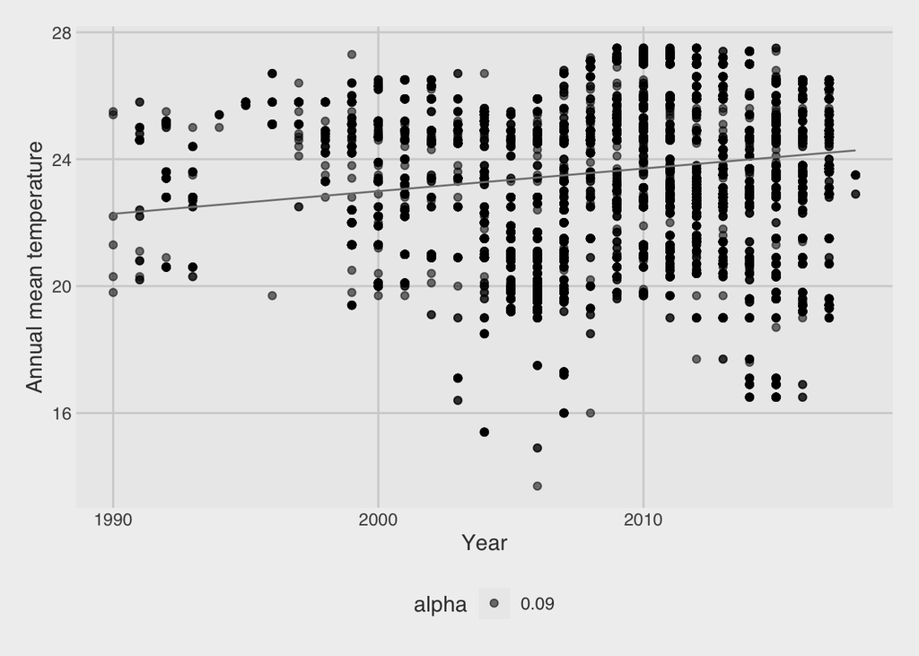

```r
g_temp <- ggplot(data = passer90, aes(x = Year, y = Annual_mean_temperature)) +
  geom_point(aes(alpha = 0.09)) +
  stat_smooth(method = "lm", se = FALSE, colour = "grey50", linewidth = 0.5, alpha = 0.1) + # FIX: size= is deprecated for lines in ggplot2 >= 3.4; use linewidth=
  theme_fivethirtyeight() +
  theme(axis.title = element_text()) +
  ylab("Annual mean temperature") +
  xlab("Year")

g_temp
```

# Elton traits to check bird diet

I am going to have a look at Elton Traits (Wilman et al. 2014) in order to check what is the functional diet category of the birds in our dataset. Elton traits’ metadata can be accessed through this [link](http://www.esapubs.org/archive/ecol/E095/178/metadata.php).

Filtering Elton Traits to the species in the wing length dataset:

```r
elton <- elton %>%
  mutate(Scientific = gsub(" ", "_", Scientific)
         ) %>%
  semi_join(passer90, by = c("Scientific" = "Binomial")
            ) # Keeping only the Elton traits entries that match the species in the passer90 tibble
```

Of the passerines in the **wing length** dataset, here is a breakdown of their dominant diet categories, according to the data from Elton traits:

```r
table(elton[,20])
```

```
## Diet-5Cat
##     FruiNect Invertebrate     Omnivore    PlantSeed
##           13           30           13            6
```

```r
(table(elton[,20])/dplyr::n_distinct(passer90$Binomial))*100
```

[output not shown]

The tables above present the counts and percetange of species, respectively, per diet category.

Only 6 species are listed in Elton Traits as having 0% of their diet consisting of invertebrates. The species that do not have any invertebrates in their diet are:

```r
cat(paste('-', elton$Scientific[which(elton$`Diet-Inv` == 0)]), sep = '\n')
```

- Euphonia_chlorotica
- Euphonia_violacea
- Coryphospingus_cucullatus
- Haplospiza_unicolor
- Sicalis_flaveola
- Tiaris_fuliginosus

All other species in the **wing length** dataset have at least some invertebrate prey as part of their diet.

# Plots

## Plotting map of sample locations

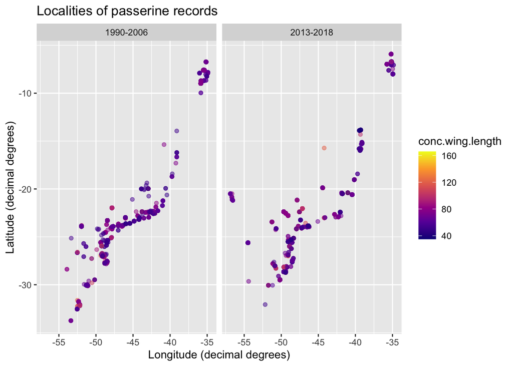

```r
# Plot only the 1st and 3rd quartile of years:
passer.quart.years <- passer90 %>%
  filter(Year <= 2006 | Year >= 2013)
passer.quart.years$period <- ifelse(passer.quart.years$Year <= 2006, '1990-2006', '2013-2018')
pts_dat <- remove_missing(passer.quart.years, vars = "conc.wing.length")

# Try to draw an OSM basemap, but DON'T let a network/API failure break the knit:
# fall back to a plain longitude/latitude scatter if the basemap can't be fetched.
basemap <- tryCatch({
  suppressMessages(require(ggmap))
  bbox <- ggmap::make_bbox(passer90$Longitude_decimal_degrees,
                           passer90$Latitude_decimal_degrees, f = 0.01)
  ggmap::get_map(bbox, source = "osm", color = "bw")
}, error = function(e) NULL)

base_layer <- if (!is.null(basemap)) ggmap::ggmap(basemap) else ggplot()

points <- base_layer +
  geom_point(aes(x = Longitude_decimal_degrees, y = Latitude_decimal_degrees,
                 colour = conc.wing.length), data = pts_dat, alpha = .5) +
  scale_color_viridis_c(option = "plasma") +
  labs(title = "Localities of passerine records",
       x = "Longitude (decimal degrees)", y = "Latitude (decimal degrees)") +
  facet_wrap(~period)

points
```

## Plotting wing length and gape width trends

Plotting the trends in wing length and gape width for the birds in the dataset. I managed to estimate averages for the 1<sup>st</sup> and the 3<sup>rd</sup> quartiles. These plots are for visualization only. I will analyse the data as continuous variation.

```r
# Using the quartile year dataset to plot spp mean wing lengths in the first quartile of the data and the 3rd quartile:
wing.by.spp <- passer.quart.years %>%
  group_by(spp, period) %>%
  summarise(mean.wing = mean(conc.wing.length, na.rm = TRUE),
            sd.wing = sd(conc.wing.length, na.rm = TRUE),
            sample.n.wing = n(),
            mean.bill.width = mean(Bill_width.mm., na.rm = TRUE),
            sd.bill = sd(Bill_width.mm., na.rm = TRUE)
            ) %>%
  mutate(time = ifelse(period == '1990-2006', 1, 2),
         size.trend = (mean.wing - lag(mean.wing)),
         size.trend1 = lead(size.trend),
         size.trend2 = coalesce(size.trend,size.trend1),
         wing.trend = ifelse(size.trend2 > 0, "Increase", "Decrease"),
         size.trend.bill = (mean.bill.width - lag(mean.bill.width)),
         size.trend.bill1 = lead(size.trend.bill),
         size.trend.bill2 = coalesce(size.trend.bill,size.trend.bill1),
         bill.trend = ifelse(size.trend.bill2 > 0, "Increase", "Decrease")
         )
```

```
## `summarise()` has regrouped the output.
## ℹ Summaries were computed grouped by spp and period.
## ℹ Output is grouped by spp.
## ℹ Use `summarise(.groups = "drop_last")` to silence this message.
## ℹ Use `summarise(.by = c(spp, period))` for per-operation grouping
##   (`?dplyr::dplyr_by`) instead.
```

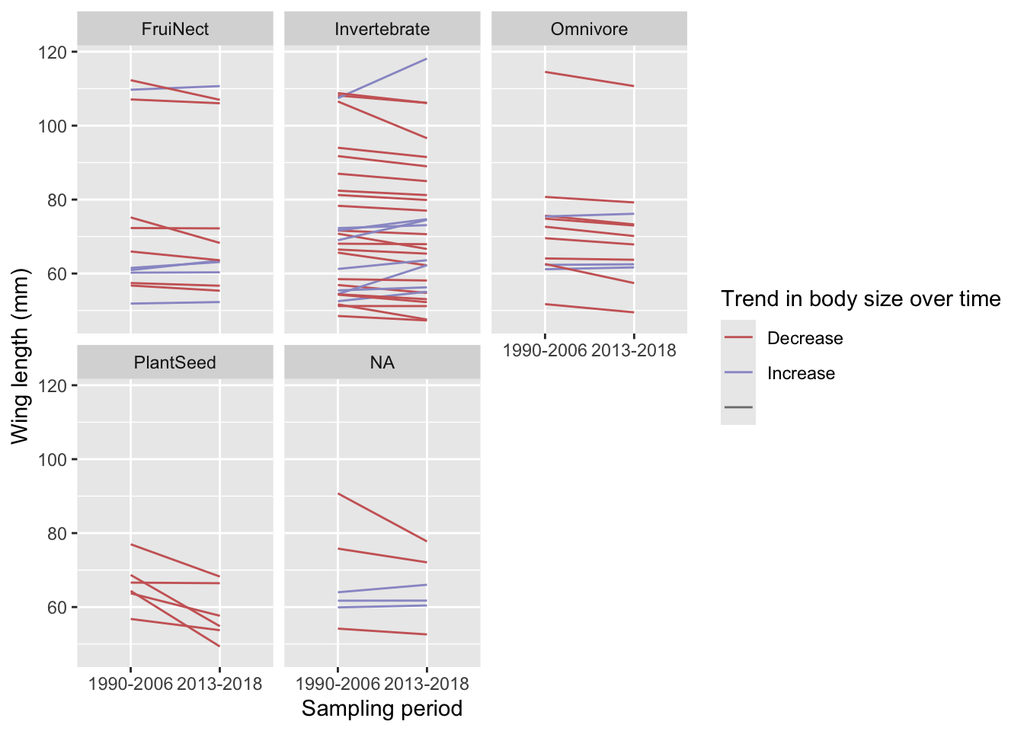

```r
# Inserting diet to make facets in the plots:
elton$Scientific = gsub(" ", "_", elton$Scientific)
wing.by.spp$Diet <- elton$`Diet-5Cat`[match(wing.by.spp$spp, elton$Scientific)]

# remove Antilophia (only present in 1st quartile):
wing.by.spp <- wing.by.spp[-1,]

# Creating color scheme for the slopes of the plot:
trend.wing.length <- ggplot(data = wing.by.spp, aes(x=period,y=mean.wing, group = spp, colour = size.trend2 > 0)) +
  geom_line() +
  scale_color_manual(name = "Trend in body size over time",
                     values = c("#CC6666","#9999CC"),
                     labels = c("Decrease", "Increase", "")) +
  labs(y = "Wing length (mm)",
       x = "Sampling period") +
  facet_wrap(~Diet)

trend.wing.length
```

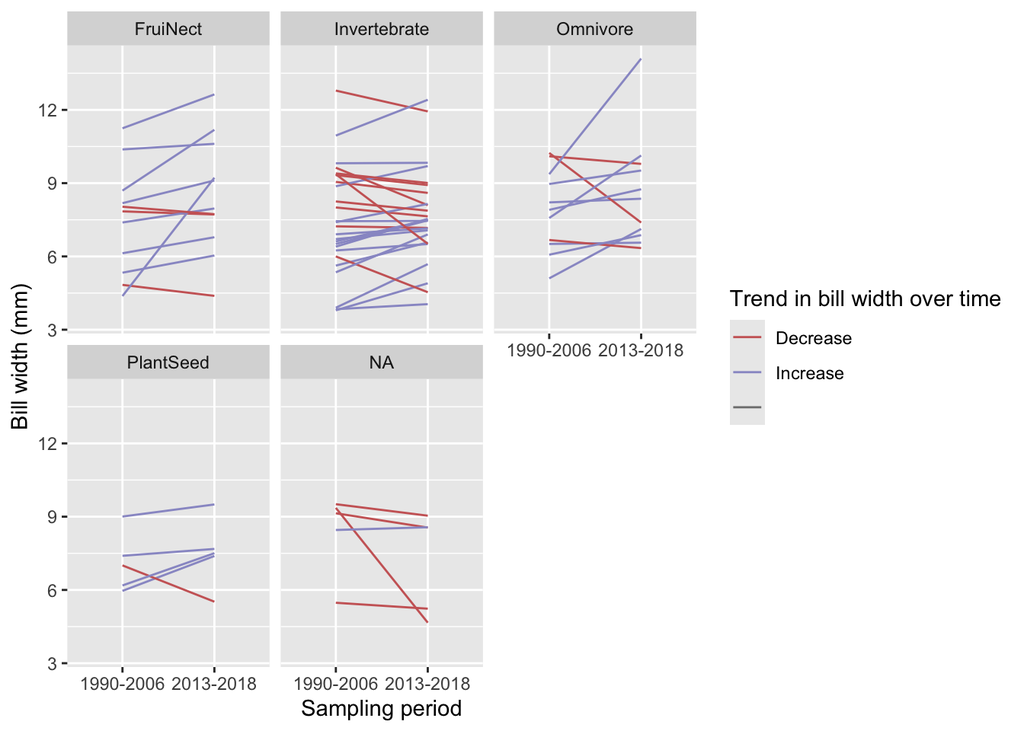

```r
trend.bill.width <- ggplot(data = wing.by.spp, aes(x=period,y=mean.bill.width, group = spp, colour = size.trend.bill2 > 0)) +
  geom_line() +
  scale_color_manual(name = "Trend in bill width over time",
                     values = c("#CC6666","#9999CC"),
                     labels = c("Decrease", "Increase", "")) +
  labs(y = "Bill width (mm)",
       x = "Sampling period") +
  facet_wrap(~Diet)

trend.bill.width
```

I plotted the average wing length for each species in the dataset for the 1<sup>st</sup> quartile (1990-2006), and the 3<sup>rd</sup> quartile (2013-2018). Each species is plotted as a trend line estimated as the difference between the average wing length in each period. Species that suffered a reduction in body size are in red and species that increase in body size between the quartiles are in blue. The number of species that decreased in body size is 47 and the number of species in which body size increased is 20.

I then investigated the trend in bill width during the same period as for wing length (described above). Species that suffered a reduction in bill width are in red and species that increase in bill width between the quartiles are in blue. The number of species that decreased in bill width is 22 and the number of species in which bill width increased is 38.

# Trend in variation of body size and gape width

Trend in variation of body size across species.

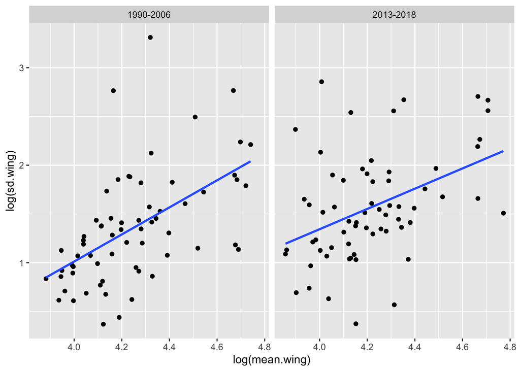

```r
### Is there a mean / sd relationship between species in wing length and bill width?
## Wing:
ggplot(wing.by.spp, aes(x=log(mean.wing), y = log(sd.wing))) +
  geom_point() +
  facet_wrap(~period) +
  stat_smooth(method = "lm", se = FALSE)
```

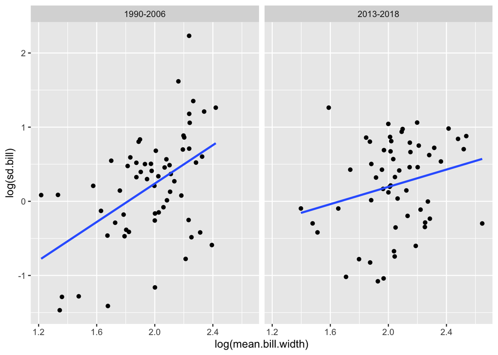

```r
## Bill:
ggplot(wing.by.spp, aes(x=log(mean.bill.width), y = log(sd.bill))) +
  geom_point() +
  facet_wrap(~period) +
  stat_smooth(method = "lm", se = FALSE)
```

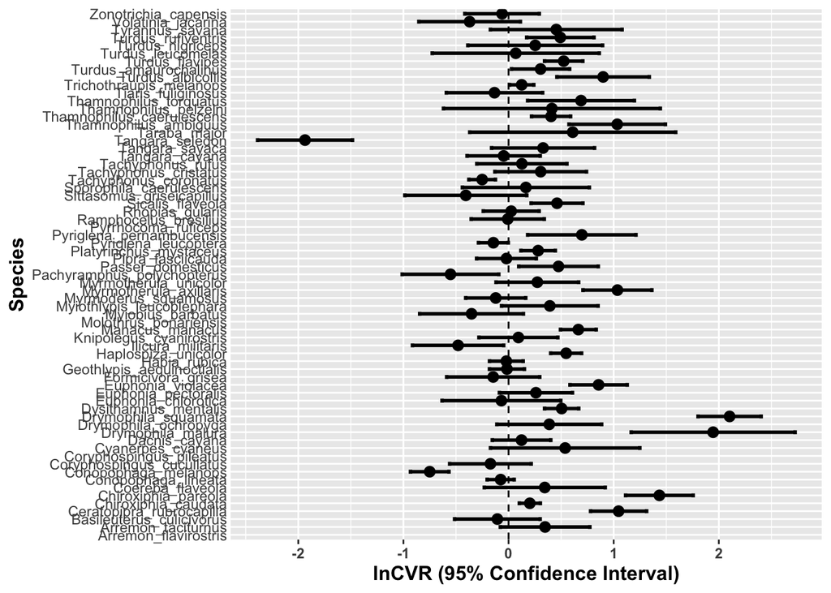

```r
### The log of the coefficient of variance ratio (lnCVR) and its sampling variance (s2lnCVR; Table 2), which assumes there is a linear relationship between the mean and variance on the natural scale (note Taylor’s Law predicts a power relationship on the natural scale).

# First transform long tibble to wide:
dat.lnCVR <- dcast(setDT(wing.by.spp),
                   spp + Diet + wing.trend + bill.trend ~ period,
                   value.var = c("mean.wing", 'sd.wing', 'mean.bill.width', 'sd.bill','sample.n.wing')
           )

#lnCVR. Here I will treat as the 'E' in the formula data from the 3rd quartile, and as 'C' data from the 1st quartile. Positive effect sizes mean that birds from the 3rd quartile have more variable body size:
dat.lnCVR$lnCVR.wing <- log((dat.lnCVR$`sd.wing_2013-2018`/dat.lnCVR$`mean.wing_2013-2018`)/(dat.lnCVR$`sd.wing_1990-2006`/dat.lnCVR$`mean.wing_1990-2006`)) + (1/(2*(dat.lnCVR$`sample.n.wing_2013-2018`-1))) - (1/(2*(dat.lnCVR$`sample.n.wing_1990-2006`-1)))

# To estimate s2.lnCVR I need a correlation across bird species of the log (ln) mean and log sd:
cor.wing.1990.2006 <- cor(log(wing.by.spp$mean.wing[wing.by.spp$period == "1990-2006"]), log(wing.by.spp$sd.wing[wing.by.spp$period == "1990-2006"]), use = "complete.obs")

cor.wing.2013.2018 <- cor(log(wing.by.spp$mean.wing[wing.by.spp$period == "2013-2018"]), log(wing.by.spp$sd.wing[wing.by.spp$period == "2013-2018"]), use = "complete.obs")

source("functions.R")
dat.lnCVR$s2.lnCVR.wing <- s2.lnCVR(dat.lnCVR$`mean.wing_1990-2006`,dat.lnCVR$`sd.wing_1990-2006`,dat.lnCVR$`sample.n.wing_1990-2006`,cor.wing.1990.2006,dat.lnCVR$`mean.wing_2013-2018`,dat.lnCVR$`sd.wing_2013-2018`,dat.lnCVR$`sample.n.wing_2013-2018`,cor.wing.2013.2018)

# FIX: 95% CI limits use the standard error (sqrt of the sampling variance),
# not the variance itself. The previous code multiplied 1.96 by s2.lnCVR
# (a variance), which mis-scaled the per-species intervals in the forest plot.
# The meta-analytic estimate from rma() below is unaffected because rma() is
# correctly passed the sampling variances via vi.
dat.lnCVR$lci.wing <- dat.lnCVR$lnCVR.wing - 1.96*sqrt(dat.lnCVR$s2.lnCVR.wing)
dat.lnCVR$uci.wing <- dat.lnCVR$lnCVR.wing + 1.96*sqrt(dat.lnCVR$s2.lnCVR.wing)

# Plot forest plot of effect sizes and 95% CIs:
p <- ggplot(data=dat.lnCVR,
           aes(x = spp,y = lnCVR.wing, ymin = lci.wing, ymax = uci.wing)
           ) +
  geom_pointrange()+
  geom_hline(yintercept =0, linetype=2)+
  xlab('Species') +
  ylab("lnCVR (95% Confidence Interval)")+
  geom_errorbar(aes(ymin=lci.wing, ymax=uci.wing),width=0.5,cex=1)+
  theme(plot.title=element_text(size=16,face="bold"),
        axis.ticks.y=element_blank(),
        axis.text.x=element_text(face="bold"),
        axis.title=element_text(size=12,face="bold"),
        strip.text.y = element_text(hjust=0,vjust = 1,angle=180,face="bold"))+
  coord_flip()
p
```

```r
# Running quick meta-analysis of lnCVR of wing length:
metareg <- rma(yi = lnCVR.wing, vi = s2.lnCVR.wing, method = "REML", data = dat.lnCVR)
summary(metareg)
```

```
##
## Random-Effects Model (k = 63; tau^2 estimator: REML)
##
##   logLik  deviance       AIC       BIC      AICc
## -55.2559  110.5118  114.5118  118.7661  114.7152
##
## tau^2 (estimated amount of total heterogeneity): 0.2989 (SE = 0.0612)
## tau (square root of estimated tau^2 value):      0.5468
## I^2 (total heterogeneity / total variability):   94.60%
## H^2 (total variability / sampling variability):  18.51
##
## Test for Heterogeneity:
## Q(df = 62) = 795.6762, p-val < .0001
##
## Model Results:
##
## estimate      se    zval    pval   ci.lb   ci.ub
##   0.2471  0.0738  3.3481  0.0008  0.1024  0.3917  ***
##
## ---
## Signif. codes:  0 '***' 0.001 '**' 0.01 '*' 0.05 '.' 0.1 ' ' 1
```

```r
# The results of this quick meta-analysis suggest that despite the overall decline in body size, the more recently sampled birds present more variability in body size than the birds that were sampled between 1990 and 2006. This is indicated by the positive lnCVR mean meta-analytic effect size.
```

Trend in variation in bill width across bird species.

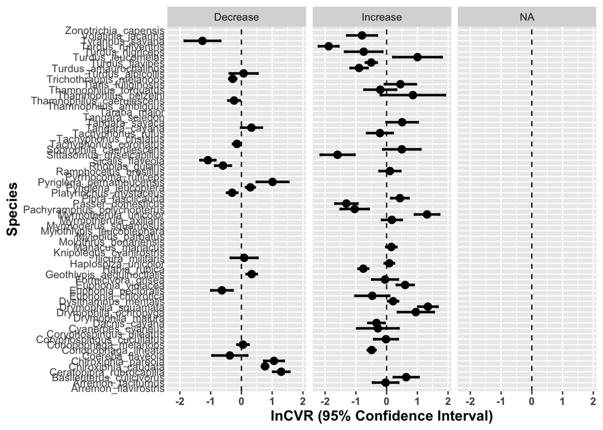

```r
### Here is the same analysis for bill width:
#lnCVR. Here I will treat as the 'E' in the formula data from the 3rd quartile, and as 'C' data from the 1st quartile. Positive effect sizes mean that birds from the 3rd quartile have more variable bill width:
dat.lnCVR$lnCVR.bill <- log((dat.lnCVR$`sd.bill_2013-2018` /dat.lnCVR$`mean.bill.width_2013-2018`)/(dat.lnCVR$`sd.bill_1990-2006` /dat.lnCVR$`mean.bill.width_1990-2006`)) + (1/(2*(dat.lnCVR$`sample.n.wing_2013-2018`-1))) - (1/(2*(dat.lnCVR$`sample.n.wing_1990-2006`-1)))

# To estimate s2.lnCVR I need a correlation across bird species of the log (ln) mean and log sd:
cor.bill.1990.2006 <- cor(log(wing.by.spp$mean.bill.width[wing.by.spp$period == "1990-2006"]), log(wing.by.spp$sd.bill[wing.by.spp$period == "1990-2006"]), use = "complete.obs")

cor.bill.2013.2018 <- cor(log(wing.by.spp$mean.bill.width[wing.by.spp$period == "2013-2018"]), log(wing.by.spp$sd.bill[wing.by.spp$period == "2013-2018"]), use = "complete.obs")

dat.lnCVR$s2.lnCVR.bill <- s2.lnCVR(dat.lnCVR$`mean.bill.width_1990-2006`,dat.lnCVR$`sd.bill_1990-2006`,dat.lnCVR$`sample.n.wing_1990-2006`,cor.bill.1990.2006,dat.lnCVR$`mean.bill.width_2013-2018`,dat.lnCVR$`sd.bill_2013-2018`,dat.lnCVR$`sample.n.wing_2013-2018`,cor.bill.2013.2018)

# FIX: use the standard error (sqrt of the sampling variance) for the CI, as above.
dat.lnCVR$lci.bill <- dat.lnCVR$lnCVR.bill - 1.96*sqrt(dat.lnCVR$s2.lnCVR.bill)
dat.lnCVR$uci.bill <- dat.lnCVR$lnCVR.bill + 1.96*sqrt(dat.lnCVR$s2.lnCVR.bill)

# Plot forest plot of effect sizes and 95% CIs:
p1 <- ggplot(data=dat.lnCVR,
           aes(x = spp,y = lnCVR.bill, ymin = lci.bill, ymax = uci.bill)
) +
  geom_pointrange()+
  geom_hline(yintercept =0, linetype=2)+
  xlab('Species') +
  ylab("lnCVR (95% Confidence Interval)")+
  geom_errorbar(aes(ymin=lci.bill, ymax=uci.bill),width=0.5,cex=1)+
  theme(plot.title=element_text(size=16,face="bold"),
        axis.ticks.y=element_blank(),
        axis.text.x=element_text(face="bold"),
        axis.title=element_text(size=12,face="bold"),
        strip.text.y = element_text(hjust=0,vjust = 1,angle=180,face="bold")) +
  facet_wrap(~bill.trend) +
  coord_flip()

p1
```

```r
# Running quick meta-analysis of lnCVR of bill width:
metareg1 <- rma(yi = lnCVR.bill, vi = s2.lnCVR.bill, method = "REML", data = dat.lnCVR)
summary(metareg1)
```

```
##
## Random-Effects Model (k = 53; tau^2 estimator: REML)
##
##   logLik  deviance       AIC       BIC      AICc
## -58.2947  116.5893  120.5893  124.4918  120.8342
##
## tau^2 (estimated amount of total heterogeneity): 0.5035 (SE = 0.1065)
## tau (square root of estimated tau^2 value):      0.7096
## I^2 (total heterogeneity / total variability):   97.14%
## H^2 (total variability / sampling variability):  34.97
##
## Test for Heterogeneity:
## Q(df = 52) = 1265.7263, p-val < .0001
##
## Model Results:
##
## estimate      se     zval    pval    ci.lb   ci.ub
##  -0.0426  0.1013  -0.4206  0.6741  -0.2413  0.1560
##
## ---
## Signif. codes:  0 '***' 0.001 '**' 0.01 '*' 0.05 '.' 0.1 ' ' 1
```

```r
# The results of this quick meta-analysis suggest that despite the overall increase in bill width, the variability in bill width is similar in birds that were sampled in the first and the third quartile of the sampling period. This is indicated by the lnCVR mean meta-analytic effect size close to 0. Thus, there is no detectable trend in the variation of bill width across species.
```

# Models

## lmer (quick) models

This chunk fits two linear mixed-effects models (`lmer`) as a preliminary check of the trends. These models are not the final models used in the analysis but provide a quick assessment of the relationships between wing length, bill width, and other predictors. `m0` models wing length as a function of year, sex, latitude, and diet. `m1` models bill width as a function of year, latitude, and diet. The `eval = FALSE` option prevents this chunk from being executed when the document is knitted.

```r
m0 <- lmer(Wing_length_right.mm. ~ scaled_yr + Sex + scaled_lat + scaled_yr*Diet + (1 + scaled_yr | Binomial),
           data = passer90,
           REML = FALSE,
           control = lmerControl(optimizer ="Nelder_Mead")
           )

summary(m0)

m1 <- lmer(Bill_width.mm. ~ scaled_yr + scaled_lat + scaled_yr*Diet + (1 + scaled_yr | Binomial),
           data = passer90,
           REML = FALSE,
           control = lmerControl(optimizer ="Nelder_Mead")
           )

summary(m1)
```

## Loading the phylogeny

```r
# Builds the analysis frame `dat` and covariance matrix `A`. At knit this runs
# only when RUN_CLIMATE = TRUE (the in-document climate model needs A); run it
# interactively any time you want the exploratory single-tree models below.
# UPGRADE (see CODE_REVIEW.md §A & §D): phylogeny now comes from McTavish et al.
# (2025), "A complete and dynamic tree of birds", and species/tree matching uses
# prepR4pcm (Nakagawa, Ortega, Mizuno, Santos et al. 2026), replacing the older
# Jetz/Hackett trees AND the manual gsub() name remaps in the wrangling chunk.
# install: pak::pak("itchyshin/prepR4pcm"); install.packages("clootl")
library(prepR4pcm)

passer90$species_name <- gsub("_", " ", passer90$Binomial)

# ABT (2018) names whose genus/epithet changed in the current eBird/Clements
# taxonomy; fix BEFORE querying clootl (which errors on names it can't find).
ebird_synonyms <- c(
  "Antilophia galeata"       = "Chiroxiphia galeata",
  "Tachyphonus cristatus"    = "Loriotus cristatus",
  "Pyrrhocoma ruficeps"      = "Thlypopsis pyrrhocoma",
  "Pyriglena pernambucensis" = "Pyriglena leuconota",
  "Tangara sayaca"           = "Thraupis sayaca",
  "Tangara cayana"           = "Stilpnia cayana",
  "Tiaris fuliginosus"       = "Asemospiza fuliginosa"
)
hit <- passer90$species_name %in% names(ebird_synonyms)
passer90$species_name[hit] <- ebird_synonyms[passer90$species_name[hit]]
spp_data <- unique(passer90$species_name)

# (1) retrieve the 100-tree cloud via prepR4pcm's clootl backend.
# Sampling across trees needs the AvesData repo downloaded once:
if (!dir.exists("AvesDataLite-main")) clootl::get_avesdata_repo(path = ".")
# get_avesdata_repo() records AVESDATA_PATH, so clootl finds the repo automatically.
got   <- pr_get_tree(spp_data, source = "clootl", n_tree = 100, cache = TRUE)
trees <- got$tree

# (2) reconcile names through the 4-stage cascade (exact -> normalised ->
#     synonym -> fuzzy), audit, then align data + prune tree. This supersedes
#     the manual name remaps and the name.check()/drop.tip() chunk below.
rec     <- reconcile_tree(passer90, trees[[1]], x_species = "species_name",
                          fuzzy = TRUE, resolve = "flag")
```

```
## ℹ Reconciling 68 data names vs 68 tree tips
```

```
## ✔ Matched 68/68 data names to tree tips
```

```r
print(reconcile_summary(rec))
```

```
##
## === Reconciliation Report ===
## Type: data_tree
## Timestamp: 2026-06-11 16:56:03
## Package: prepR4pcm 0.5.0.9000
## Authority: COL (version: latest)
## Rank: species
##
## --- Match Summary ---
##   Exact:       0 / 68
##   Normalized:  68 / 68
##   Synonym:     0 / 68
##   Fuzzy:       0 / 68
##   Manual:      0 / 68
##   Unresolved:  0 (x only) + 0 (y only)
##
## --- Normalized Matches (68) ---
##   "Trichothraupis melanops" -> "Trichothraupis_melanops"  ['Trichothraupis melanops' normalised to 'Trichothraupis melanops']
##   "Turdus leucomelas" -> "Turdus_leucomelas"  ['Turdus leucomelas' normalised to 'Turdus leucomelas']
##   "Haplospiza unicolor" -> "Haplospiza_unicolor"  ['Haplospiza unicolor' normalised to 'Haplospiza unicolor']
##   "Platyrinchus mystaceus" -> "Platyrinchus_mystaceus"  ['Platyrinchus mystaceus' normalised to 'Platyrinchus mystaceus']
##   "Chiroxiphia caudata" -> "Chiroxiphia_caudata"  ['Chiroxiphia caudata' normalised to 'Chiroxiphia caudata']
##   "Conopophaga lineata" -> "Conopophaga_lineata"  ['Conopophaga lineata' normalised to 'Conopophaga lineata']
##   "Pyriglena leucoptera" -> "Pyriglena_leucoptera"  ['Pyriglena leucoptera' normalised to 'Pyriglena leucoptera']
##   "Manacus manacus" -> "Manacus_manacus"  ['Manacus manacus' normalised to 'Manacus manacus']
##   "Turdus amaurochalinus" -> "Turdus_amaurochalinus"  ['Turdus amaurochalinus' normalised to 'Turdus amaurochalinus']
##   "Sittasomus griseicapillus" -> "Sittasomus_griseicapillus"  ['Sittasomus griseicapillus' normalised to 'Sittasomus griseicapillus']
##   "Thamnophilus caerulescens" -> "Thamnophilus_caerulescens"  ['Thamnophilus caerulescens' normalised to 'Thamnophilus caerulescens']
##   "Dysithamnus mentalis" -> "Dysithamnus_mentalis"  ['Dysithamnus mentalis' normalised to 'Dysithamnus mentalis']
##   "Turdus flavipes" -> "Turdus_flavipes"  ['Turdus flavipes' normalised to 'Turdus flavipes']
##   "Basileuterus culicivorus" -> "Basileuterus_culicivorus"  ['Basileuterus culicivorus' normalised to 'Basileuterus culicivorus']
##   "Tachyphonus coronatus" -> "Tachyphonus_coronatus"  ['Tachyphonus coronatus' normalised to 'Tachyphonus coronatus']
##   "Ilicura militaris" -> "Ilicura_militaris"  ['Ilicura militaris' normalised to 'Ilicura militaris']
##   "Turdus rufiventris" -> "Turdus_rufiventris"  ['Turdus rufiventris' normalised to 'Turdus rufiventris']
##   "Turdus albicollis" -> "Turdus_albicollis"  ['Turdus albicollis' normalised to 'Turdus albicollis']
##   "Zonotrichia capensis" -> "Zonotrichia_capensis"  ['Zonotrichia capensis' normalised to 'Zonotrichia capensis']
##   "Coereba flaveola" -> "Coereba_flaveola"  ['Coereba flaveola' normalised to 'Coereba flaveola']
##   ... and 48 more
##
```

```r
aligned <- reconcile_apply(rec, data = passer90, tree = trees[[1]],
                           species_col = "species_name", drop_unresolved = TRUE)
```

```
## ℹ Tree has 68 tips after alignment
```

```r
# Analysis frame + a single representative covariance matrix A, using the SAME
# conventions as atlantic_parallel.R (species_name grouping, underscored tips,
# ultrametric). Any single-tree exploratory model below uses `dat` and `A`.
library(phytools)
dat <- aligned$data
dat$species_name <- gsub(" ", "_", dat$species_name); dat$spp <- dat$species_name
rep_tree <- aligned$tree; rep_tree$tip.label <- gsub(" ", "_", rep_tree$tip.label)
if (!ape::is.ultrametric(rep_tree)) rep_tree <- phytools::force.ultrametric(rep_tree, method = "nnls")
```

```
## *                          Note:                              *
## *    force.ultrametric does not include a formal method to    *
## *    ultrametricize a tree & should only be used to coerce    *
## *   a phylogeny that fails is.ultrametric due to rounding --  *
## *    not as a substitute for formal rate-smoothing methods.   *
```

```r
inv.phylo <- inverseA(rep_tree, nodes = "TIPS", scale = TRUE)
A <- solve(inv.phylo$Ainv); rownames(A) <- rownames(inv.phylo$Ainv)

# CANONICAL, REPORTED phylogenetic results = the 50-tree, Rubin-pooled fits from
# atlantic_parallel.R (wing) and atlantic_parallel_bill.R (bill); their saved
# outputs are loaded and summarised in the results chunks further below. The
# single-tree model chunks here are EXPLORATORY only (all eval = FALSE).
```

> **Superseded.** The old workflow here sampled 50 Jetz/BirdTree trees with `name.check()` + `drop.tip()` and saved `trees_passer.rda`. That is replaced by the prepR4pcm reconciliation above (`reconcile_apply()` aligns data and tree and prunes in one auditable step) and by the multi-tree fitting in `atlantic_parallel.R`. The covariance matrix `A` and analysis frame `dat` are now built in the phylogeny chunk above, so no separate `name.check`/`load("trees_passer.rda")` step is needed.

## Multiple imputation wing length

Before running the multi-level Bayesian model, I will use multiple imputation to impute missing data with the package *mice*. The idea is to create 5 new datasets with fully imputed data.

```r
require(lattice)
require(pan)
require(multilevel)

# Exploring the missing data pattern:
md.pattern(passer90, rotate.names = TRUE)

histogram(~ as.numeric(as.factor(Binomial)) | is.na(conc.wing.length), data=passer90)
# We do see that the histogram for the missing wing length (TRUE) is further to the right than the histogram for observed wing length (FALSE). This would indicate a right-tailed MAR missingness.

histogram(~ as.numeric(as.factor(Binomial)) | is.na(Latitude_decimal_degrees), data=passer90)
# We do see that the histogram for the missing Latitude (TRUE) is centered on the histogram for observed Latitude (FALSE). This would indicate a non-skewed MAR missingness.

# Have a look at the intraclass correlation (ICC) for the incomplete variables: Wing length:
ICC1(aov(conc.wing.length ~ Binomial, data = passer90))

# Impute the passer90 dataset with mice using imputation method norm
ini <- mice(passer90, maxit = 0)
meth <- ini$meth
meth

# NOTE: hardcoded column indices c(12,13) are fragile and break if the column
# order of passer90 changes. Prefer name-based indexing, e.g.:
#   meth[c("conc.wing.length", "ln_conc_wing_length")] <- "norm"
# Verify the intended variables before running.
meth[c(12,13)] <- "norm"
meth

pred <- ini$pred
pred

start_time <- Sys.time()
#passer90_imp <- mice(passer90, meth = meth, pred = pred, print = FALSE)
end_time <- Sys.time();end_time - start_time

# Compare the means of the variables in the first imputed dataset and in the incomplete dataset:
summary(complete(passer90_imp))

summary(passer90)

# Compare the ICC’s of the variables in the first imputed dataset with those in the incomplete dataset:
data.frame(vars = names(passer90[12]),
           observed = c(ICC1(aov(conc.wing.length ~ Binomial, passer90))
                        ),
           norm     = c(ICC1(aov(conc.wing.length ~ Binomial, complete(passer90_imp)))
                        ))

# Now impute the passer90 dataset again with mice using imputation method norm for the same variables as before, but now include Binomial as a predictor for all variables:
pred <- ini$pred
pred[, "Binomial"] <- 1
pred

start_time <- Sys.time()
#passer90_imp1 <- mice(passer90, meth = meth, pred = pred, print = FALSE)
end_time <- Sys.time();end_time - start_time

# Compare the ICC’s of the variables in the first imputed dataset with those in the incomplete dataset and the 2nd imputed set:
data.frame(vars = names(passer90[c(8, 6)]),
           observed = c(ICC1(aov(Wing_length_right.mm. ~ Binomial, passer90)),
                        ICC1(aov(Latitude_decimal_degrees ~ Binomial, passer90))
                        ),
           norm     = c(ICC1(aov(Wing_length_right.mm. ~ Binomial, complete(passer90_imp))),
                        ICC1(aov(Latitude_decimal_degrees ~ Binomial, complete(passer90_imp)))
                        ),
           normBinomial     = c(ICC1(aov(Wing_length_right.mm. ~ Binomial, complete(passer90_imp1))),
                        ICC1(aov(Latitude_decimal_degrees ~ Binomial, complete(passer90_imp1)))
                        )
           )

plot(passer90_imp1, "conc.wing.length")

# Add 10 more iterations:
#passer90_imp2 <- mice.mids(passer90_imp1, maxit = 10)

plot(passer90_imp2, "conc.wing.length")

# Add 20 more iterations:
#passer90_imp3 <- mice.mids(passer90_imp2, maxit = 20, print = FALSE)

plot(passer90_imp3, "conc.wing.length")

# Plot the densities of the observed and imputed data (use passer90_imp3) with the function densityplot().
densityplot(passer90_imp3)

# Impute the passer90 data once more where you use predictive mean matching and include all variables as predictors. Name the object passer90_imp4.
passer90_imp4 <- mice(passer90, print = FALSE, seed = 20240101) # FIX: set seed for reproducible imputations

densityplot(passer90_imp4, ~conc.wing.length)
plot(passer90_imp4)

passer90_imp4a <- mice.mids(passer90_imp4, maxit = 20, print = FALSE)
plot(passer90_imp4a)
densityplot(passer90_imp4a, ~conc.wing.length)

save(passer90_imp4a, file = "passer90_imp4a.rda")
```

### Multilevel models with imputed data and phylogeny

Here is a multi-level Bayesian model of the response variable *Wing length* including the phylogeny of the species in question. If I run with the original data set, even though we have over 14k entries, there are only 4.6k complete entries that **brm** will use to estimate parameters. This model is running over the imputed dataset passer90_imp4a:

```r
# EXPLORATORY (eval = FALSE). The REPORTED wing result is the 50-tree,
# Rubin-pooled fit from atlantic_parallel.R. To run this consistently, impute the
# RECONCILED frame `dat` (so names match A's species_name), not the old passer90.
imp <- mice::mice(dat, print = FALSE, seed = 20240101)

start_time <- Sys.time()
brm.imputed <- brm_multiple(conc.wing.length ~ 1 + Sex + scaled_yr + scaled_lat + (1 + scaled_yr || spp) + (1 | gr(species_name, cov = A)),
            data2 = list(A = A),
            data = imp,
            family = gaussian,
            prior = c(prior(normal(71, 15), class = Intercept),
                      prior(normal(0, 10), class = b),
                      prior(cauchy(0, 1), class = sd),
                      prior(cauchy(0, 1), class = sigma)),
            chains = 2,
            cores = 2,
            control = list(max_treedepth = 12))

end_time <- Sys.time();end_time - start_time

save(brm.imputed, file = "brm_imputed.rda")
```

## brm model of wing length

I will keep this full model here for a while. I will run the model from the chunk above as a test model with the multiple imputation data. Glauco made some comments that I have to check[^4]

```r
# EXPLORATORY single-consensus-tree fit (eval = FALSE). The REPORTED wing result
# is the 50-tree, Rubin-pooled fit from atlantic_parallel.R (loaded below).
start_time <- Sys.time()
brm0 <- brm(conc.wing.length ~ 1 + Sex + scaled_yr + scaled_lat + (1 + scaled_yr || spp) + (1 | gr(species_name, cov = A)),
            data2 = list(A = A),
            data = dat,
            family = gaussian,
            prior = c(prior(normal(71, 15), class = Intercept),
                      prior(normal(0, 10), class = b),
                      prior(cauchy(0, 1), class = sd),
                      prior(cauchy(0, 1), class = sigma)),
            iter = 1500,
            warmup = 1000,
            chains = 4,
            cores = 4,
            control = list(max_treedepth = 12))

end_time <- Sys.time();end_time - start_time

save(brm0, file = "brm0.rda")
```

Summary and convergence checks for the exploratory single-tree fit (the `brm0.rda` here is the older single-consensus-tree object; the REPORTED result is the multi-tree summary further below). Not run at knit.

```r
load("brm0.rda")

summary(brm0)

mcmc_plot(brm0)
plot(conditional_effects(brm0))
pp_check(brm0)
```

## Upgraded model: body size vs. time-resolved climate

This model replaces *year* as a proxy with the **actual temperature** each bird experienced, extracted per record and year by `climate_extraction.R` (WorldClim CRU-TS 4.09 downscaled). Year is retained to separate climate tracking from other temporal change. Not evaluated here (requires the downloaded climate rasters).

```r
passer90_clim <- readRDS("passer90_climate.rds")

brm_climate <- brm(conc.wing.length ~ 1 + Sex + scaled_tmean + scaled_lat + scaled_yr +
            (1 + scaled_tmean || spp) + (1 | gr(species_name, cov = A)),
            data = passer90_clim,
            data2 = list(A = A),
            family = gaussian,
            prior = c(prior(normal(71, 15), class = Intercept),
                      prior(normal(0, 10), class = b),
                      prior(cauchy(0, 1), class = sd),
                      prior(cauchy(0, 1), class = sigma)),
            iter = 2000, warmup = 1000, chains = 4, cores = 4,
            control = list(max_treedepth = 12, adapt_delta = 0.95))
save(brm_climate, file = "brm_climate.rda")
summary(brm_climate)
```

## brm model of bill width

EXPLORATORY single-consensus-tree bill model (eval = FALSE). The REPORTED bill result is the 50-tree, Rubin-pooled fit from `atlantic_parallel_bill.R` (loaded in the bill results chunk below).

```r
# Defining the priors to use in the gape model:
start_time <- Sys.time()
brm0.gape <- brm(Bill_width.mm. ~ 1 + scaled_yr + scaled_lat + (1 + scaled_yr || spp) + (1 | gr(species_name, cov = A)),
            data2 = list(A = A),
            data = dat,
            family = gaussian,
            prior = c(prior(normal(9, 2.5), class = Intercept),
                      prior(normal(0, 10), class = b),
                      prior(cauchy(0, 1), class = sd),
                      prior(cauchy(0, 1), class = sigma)),
            iter = 1500,
            warmup = 1000,
            chains = 2,
            cores = 2
            )
end_time <- Sys.time();end_time - start_time

save(brm0.gape, file = "brm0.gape.model.rda")
```

### Bill-width results (reported): 50-tree, Rubin-pooled fit

Loads the output of `atlantic_parallel_bill.R`.

```r
load("brm_bill_multiphylo.rda")   # provides: bill_fits, bill_rubin_summary, bill_sig

bill_rubin_summary                # pooled fixed effects (Wald–Rubin 95% CI)
```

```
##                       par   estimate         se       lower      upper
## b_Intercept   b_Intercept  8.1747498 1.04822005  6.12023849 10.2292611
## b_scaled_yr   b_scaled_yr  0.1119188 0.07414231 -0.03340012  0.2572378
## b_scaled_lat b_scaled_lat -0.3758131 0.04869482 -0.47125494 -0.2803712
```

```r
# pooled phylogenetic signal across the 50 trees:
round(c(mean = mean(bill_sig), lwr = quantile(bill_sig, .025), upr = quantile(bill_sig, .975)), 3)
```

```
##      mean  lwr.2.5% upr.97.5%
##     0.553     0.489     0.616
```

## Multi-level model with phylogenetic uncertainty

I asked Ari to run the multilevel model of **Wing length** on the server so that we could run the model over a sample of 50 tree topologies, in order to incorporate phylogenetic uncertainty. The code to run that model is in the file *atlantic_parallel.R* (included in the repository). We saved the results of this run as a list of 50 per-tree fits in **brm0_multiphylo.rda**. Below, I load this file to check its summary and diagnostics.

```r
# Output of atlantic_parallel.R: fits (50 per-tree brmsfit objects),
# rubin_summary (Wald–Rubin pooled fixed effects), and clootl_version.
load("brm0_multiphylo.rda")

rubin_summary                     # REPORTED wing-length fixed effects (pooled across trees)
```

```
##                       par   estimate         se      lower      upper
## b_Intercept   b_Intercept 71.0900159 9.11523100 53.2241631 88.9558686
## b_SexMale       b_SexMale  2.5589054 0.10735796  2.3484838  2.7693270
## b_scaled_yr   b_scaled_yr -0.6648390 0.19498069 -1.0470012 -0.2826769
## b_scaled_lat b_scaled_lat -0.4272414 0.09564439 -0.6147044 -0.2397784
```

```r
# pooled phylogenetic signal (proportion of variance) across the 50 trees:
wing_sig <- sapply(fits, function(f)
  hypothesis(f,
    "sd_species_name__Intercept^2 / (sd_species_name__Intercept^2 + sd_spp__Intercept^2 + sd_spp__scaled_yr^2 + sigma^2) = 0",
    class = NULL)$hypothesis$Estimate)
round(c(mean = mean(wing_sig), lwr = quantile(wing_sig, .025), upr = quantile(wing_sig, .975)), 3)
```

```
##      mean  lwr.2.5% upr.97.5%
##     0.950     0.938     0.960
```

Posterior of the year effect, pooled across the 50 per-tree fits:

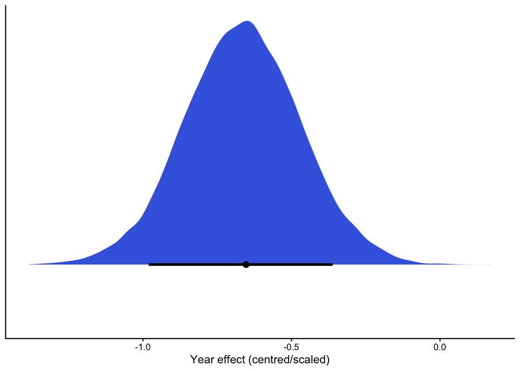

```r
require("tidybayes")
beta_yr <- unlist(lapply(fits, function(f) as_draws_df(f)$b_scaled_yr))

tibble::tibble(beta_yr_ef = beta_yr) %>%
  ggplot(aes(x = beta_yr_ef)) +
  geom_density(linewidth = 0, fill = "royalblue") +
  stat_pointinterval(aes(y = 0), point_interval = mode_hdi, .width = .89) +
  scale_y_continuous(NULL, breaks = NULL) +
  labs(x = "Year effect (centred/scaled)") +
  theme_classic()
```

```r
# EXPLORATORY (eval = FALSE): body mass is not part of the main analysis. Uses the
# same synced conventions (dat, species_name, A). For a reported result it would
# need the multi-tree treatment in atlantic_parallel.R.
start_time <- Sys.time()
brm1 <- brm(Body_mass.g. ~ 1 + Sex + scaled_yr + scaled_lat + (1 + scaled_yr || spp) + (1 | gr(species_name, cov = A)),
            data2 = list(A = A),
            data = dat,
            family = gaussian,
            prior = c(prior(normal(71, 15), class = Intercept),
                      prior(normal(0, 10), class = b),
                      prior(cauchy(0, 1), class = sd),
                      prior(cauchy(0, 1), class = sigma)),
            iter = 2000,
            warmup = 1000,
            chains = 3,
            cores = 3,
            control = list(max_treedepth = 12))

end_time <- Sys.time();end_time - start_time

summary(brm1)
mcmc_plot(brm1)
#brms::launch_shinystan(brm0)

plot(conditional_effects(brm1), points = TRUE)
pp_check(brm1)

hyp <- "sd_species_name__Intercept^2 / (sd_species_name__Intercept^2 + sd_spp__Intercept^2 + sigma^2) = 0"
(hyp <- hypothesis(brm1, hyp, class = NULL))
```

# Arthropod abundance over time analysis

This section of the analysis investigates the temporal trend in arthropod abundance, which is a potential driver of the observed changes in bird body size. The data for this analysis comes from the PREDICTS project, a large database of biodiversity records.

This chunk loads the full PREDICTS dataset via the official `predictsr` package (Duffin, Biodiversity Futures Lab), which downloads the open-access extract (2016 + 2022 releases) straight from the NHM Data Portal API and caches it — no manual CSV download or local path needed. install.packages(“predictsr”). `eval = FALSE` because the first call downloads a large file; run it once and the cached copy (and chunk cache) are reused thereafter.

NOTE: the original analysis used the 2016 release only; predictsr now returns 2016 + 2022 combined (more data), so re-running may shift the estimates slightly. To reproduce the 2016-only result, filter on the release/source year.

```r
dat <- LoadPredictsData("predicts_extract.rds")  # downloads + caches to this file; reused on later runs
```

```r
# Playing with data from WHOLE Brazil to see what is going on:
dat_test <- dat %>%
        filter(Phylum == "Arthropoda", Diversity_metric_type == "Abundance", UN_subregion == "South America", Class %in% c("Insecta", "Arachnida")) %>%
        mutate(
          scaled_yr = as.numeric(scale(Sample_midpoint)),
          log_abundance = log(Effort_corrected_measurement),
          Measurement = as.integer(Measurement),
          Class = as.factor(Class)
) # I logged the abundance divided by sampling effort in order to normalize the data

rm("dat")
save(dat_test, file = "dat_test.rds")
```

Loading the subset of South America data that I had already saved as a .rds file

```r
load("dat_test.rds")

dat_test <- dat_test %>%
      mutate(
        Class = as.factor(Class),
        log_sampling = log(Sampling_effort) # logging sampling effort to use as offset in Poisson model
        )
```

Plotting the relationship between year and abundance of arthropods in Brazil.

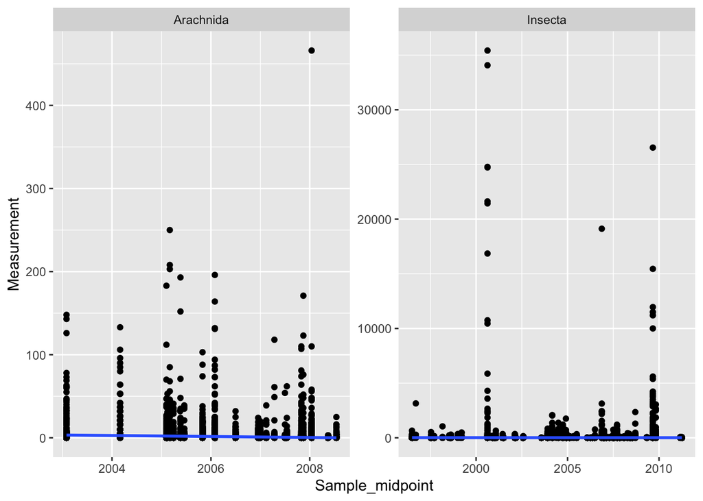

```r
g_test <-  ggplot(data = dat_test, aes(x = Sample_midpoint, y = Measurement)) +
                  geom_point() +
                  stat_smooth(method = "lm", se = FALSE) +
                  facet_wrap(~Class, scales = "free")

g_test
```

## Arthropod abundance brm model

Negative binomial model with offset to investigate the relationship between the predictor **year** and the response (count) abundance of arthropods in Brazil.

```r
start_time <- Sys.time()
brm1 <-
  brm(data = dat_test, family = negbinomial,
      Measurement ~ 1 + offset(log_sampling) + scaled_yr,
      prior = c(prior(normal(0, 10), class = Intercept),
                prior(normal(0, 1), class = b),
                prior(gamma(0.01, 0.01), class = shape) # the brms default
                ),
      cores = 2,
      chains = 2,
      iter = 1000)
end_time <- Sys.time();end_time - start_time

save(brm1, file = "brm_arthro_abund.rda")
```

Loading arthropod abundance model to check summary and convergence.

```r
load("brm_arthro_abund.rda")

summary(brm1)
```

```
##  Family: negbinomial
##   Links: mu = log
## Formula: Measurement ~ 1 + offset(log_sampling) + scaled_yr
##    Data: dat_test (Number of observations: 73046)
##   Draws: 2 chains, each with iter = 1000; warmup = 500; thin = 1;
##          total post-warmup draws = 1000
##
## Regression Coefficients:
##           Estimate Est.Error l-95% CI u-95% CI Rhat Bulk_ESS Tail_ESS
## Intercept    -0.12      0.02    -0.16    -0.09 1.00      979      575
## scaled_yr    -0.68      0.03    -0.73    -0.63 1.00      871      771
##
## Further Distributional Parameters:
##       Estimate Est.Error l-95% CI u-95% CI Rhat Bulk_ESS Tail_ESS
## shape     0.04      0.00     0.04     0.04 1.00     1254      823
##
## Draws were sampled using sampling(NUTS). For each parameter, Bulk_ESS
## and Tail_ESS are effective sample size measures, and Rhat is the potential
## scale reduction factor on split chains (at convergence, Rhat = 1).
```

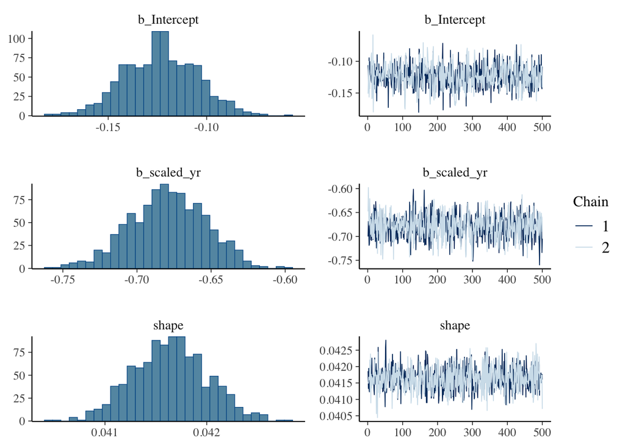

```r
plot(brm1)
```

```r
fixef(brm1)[1:2, ] %>%
  exp()
```

```
##            Estimate Est.Error      Q2.5     Q97.5
## Intercept 0.8840136  1.018750 0.8529115 0.9167516
## scaled_yr 0.5070207  1.026081 0.4819546 0.5322808
```

```
## Ignoring unknown labels:
## • fill : "NA"
## • colour : "NA"
## Ignoring unknown labels:
## • fill : "NA"
## • colour : "NA"
```

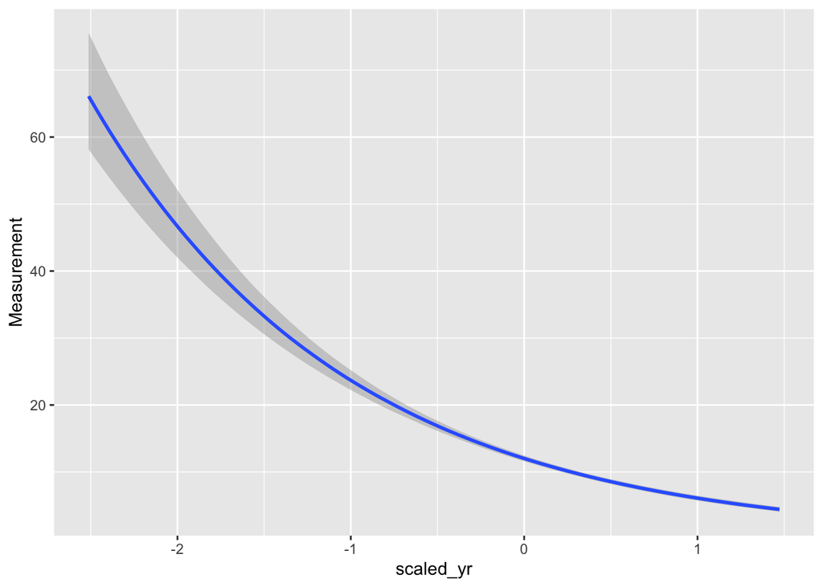

```r
plot(conditional_effects(brm1))
```

```r
pp_check(brm1)
```

```
## Using 10 posterior draws for ppc type 'dens_overlay' by default.
```

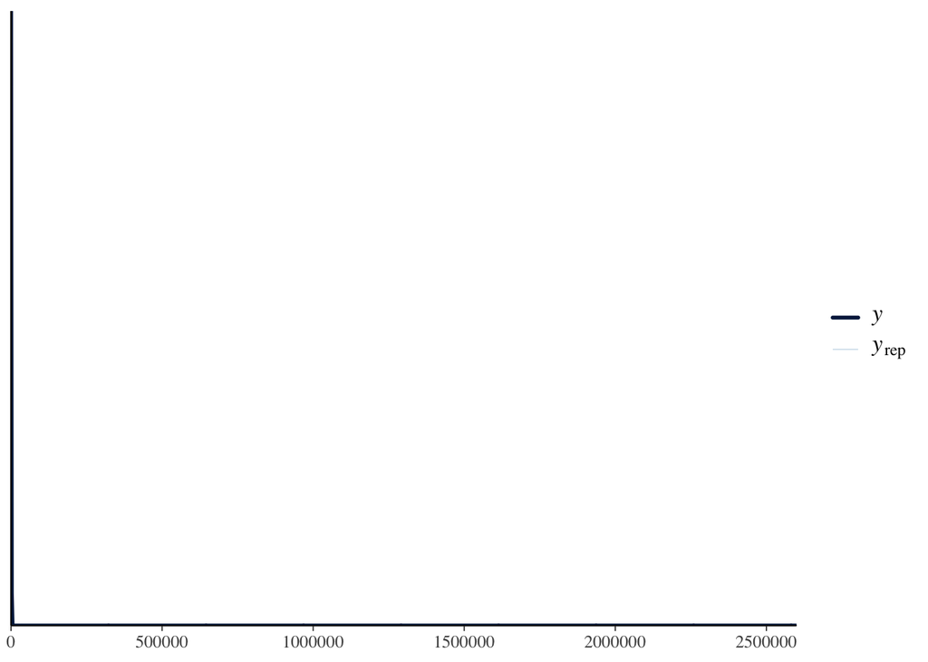

Glauco has rightfully suggested that I removed ants from the abundance dataset to see how sensitive it is to these arthropods. While most passerines rarely consume ant workers, some species opportunistically take flying ant reproductives (alates) during nuptial flights (**helms_are_2016?**), so complete exclusion of Formicidae is a conservative assumption. We retain this ant-exclusion model as a sensitivity check. Negative binomial model with offset to investigate the relationship between the predictor **year** and the response (count) abundance of arthropods in Brazil.

```r
dat_no_ants <- dat_test %>%
        filter(Family != "Formicidae"
               )

save(dat_no_ants, file = "dat_no_ants.rds")
```

Model with no ant abundance:

```r
start_time <- Sys.time()
brm_no_ants <-
  brm(data = dat_no_ants, family = negbinomial,
      Measurement ~ 1 + offset(log_sampling) + scaled_yr,
      prior = c(prior(normal(0, 10), class = Intercept),
                prior(normal(0, 1), class = b),
                prior(gamma(0.01, 0.01), class = shape) # the brms default
                ),
      cores = 2,
      chains = 2,
      iter = 1000)
end_time <- Sys.time();end_time - start_time

save(brm_no_ants, file = "brm_arthro_abund_no_ants.rda")
```

Loading arthropod abundance model (without ants) to check summary and convergence.

```r
load("brm_arthro_abund_no_ants.rda")

summary(brm_no_ants)
```

```
##  Family: negbinomial
##   Links: mu = log
## Formula: Measurement ~ 1 + offset(log_sampling) + scaled_yr
##    Data: dat_no_ants (Number of observations: 56895)
##   Draws: 2 chains, each with iter = 1000; warmup = 500; thin = 1;
##          total post-warmup draws = 1000
##
## Regression Coefficients:
##           Estimate Est.Error l-95% CI u-95% CI Rhat Bulk_ESS Tail_ESS
## Intercept    -0.52      0.02    -0.55    -0.48 1.00     1177      795
## scaled_yr    -0.89      0.03    -0.95    -0.82 1.01      984      840
##
## Further Distributional Parameters:
##       Estimate Est.Error l-95% CI u-95% CI Rhat Bulk_ESS Tail_ESS
## shape     0.04      0.00     0.04     0.04 1.00     1202      878
##
## Draws were sampled using sampling(NUTS). For each parameter, Bulk_ESS
## and Tail_ESS are effective sample size measures, and Rhat is the potential
## scale reduction factor on split chains (at convergence, Rhat = 1).
```

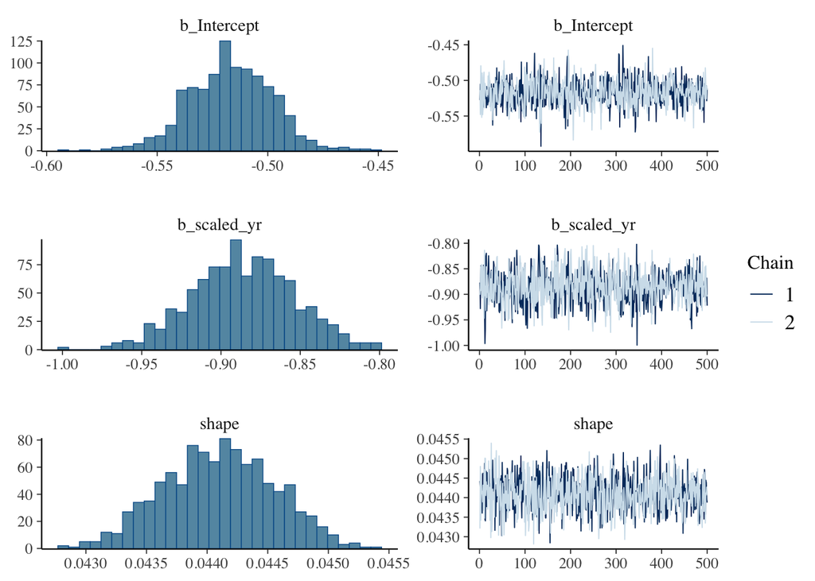

```r
plot(brm_no_ants)
```

```r
fixef(brm_no_ants)[1:2, ] %>%
  exp()
```

```
##            Estimate Est.Error      Q2.5     Q97.5
## Intercept 0.5963921  1.019024 0.5748341 0.6173635
## scaled_yr 0.4123681  1.033094 0.3873648 0.4384464
```

```
## Ignoring unknown labels:
## • fill : "NA"
## • colour : "NA"
## Ignoring unknown labels:
## • fill : "NA"
## • colour : "NA"
```

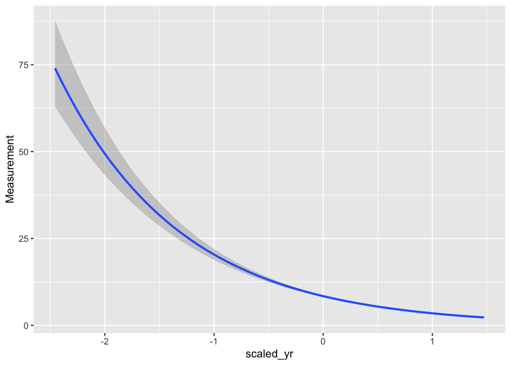

```r
plot(conditional_effects(brm_no_ants))
```

```r
pp_check(brm_no_ants)
```

```
## Using 10 posterior draws for ppc type 'dens_overlay' by default.
```

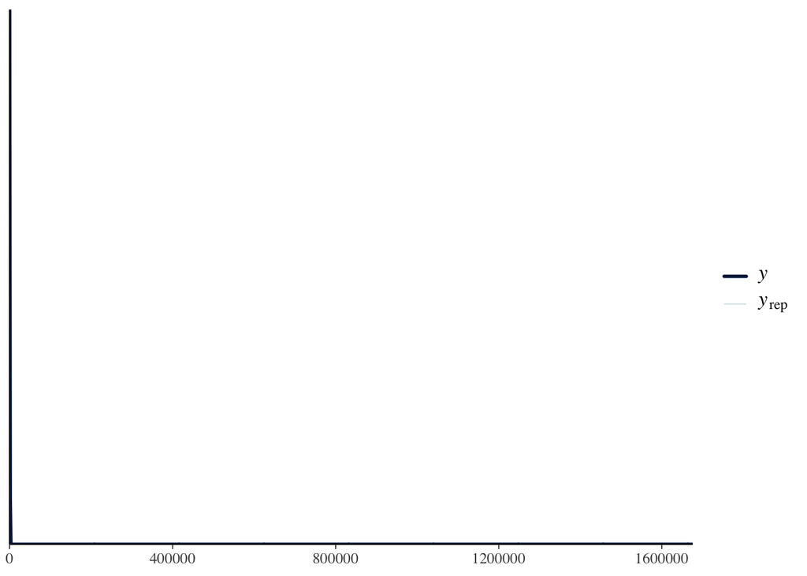

Another idea that Glauco gave me was to use only invertebrate abundances from forest biomes and avoid the grasslands and savannas. So here is the **main** analysis using a subset restricted to forest biomes. Ants are now included because some passerines opportunistically predate alates during nuptial flights (**helms_are_2016?**); the ant-exclusion variant above serves as the sensitivity check.

```r
dat_no_grassland <- dat_test %>%
        filter(Biome %in% c("Mangroves", "Mediterranean Forests, Woodlands & Scrub","Temperate Broadleaf & Mixed Forests","Tropical & Subtropical Dry Broadleaf Forests","Tropical & Subtropical Moist Broadleaf Forests")
               )

save(dat_no_grassland, file = "dat_no_grassland.rds")
```

## Arthropod abundance model excluding open biomes (ants included)

Main model — forest biomes only, all arthropods including ants:

```r
load("dat_no_grassland.rds")

start_time <- Sys.time()
brm_no_grass <-
  brm(data = dat_no_grassland, family = negbinomial,
      Measurement ~ 1 + offset(log_sampling) + scaled_yr,
      prior = c(prior(normal(0, 10), class = Intercept),
                prior(normal(0, 1), class = b),
                prior(gamma(0.01, 0.01), class = shape) # the brms default
                ),
      cores = 2,
      chains = 2,
      iter = 1000)
end_time <- Sys.time();end_time - start_time

save(brm_no_grass, file = "brm_no_grass.rda")
```

Loading arthropod abundance model (forest biomes, ants included) to check summary and convergence.

```r
load("brm_no_grass.rda")

summary(brm_no_grass)
```

[output not shown]

[figure not shown]

```r
plot(brm_no_grass)
```

```r
fixef(brm_no_grass)[1:2, ] %>%
  exp()
```

```
##            Estimate Est.Error      Q2.5     Q97.5
## Intercept 0.5729698  1.020671 0.5508549 0.5967704
## scaled_yr 0.2464882  1.033795 0.2312631 0.2636074
```

```
## Ignoring unknown labels:
## • fill : "NA"
## • colour : "NA"
## Ignoring unknown labels:
## • fill : "NA"
## • colour : "NA"
```

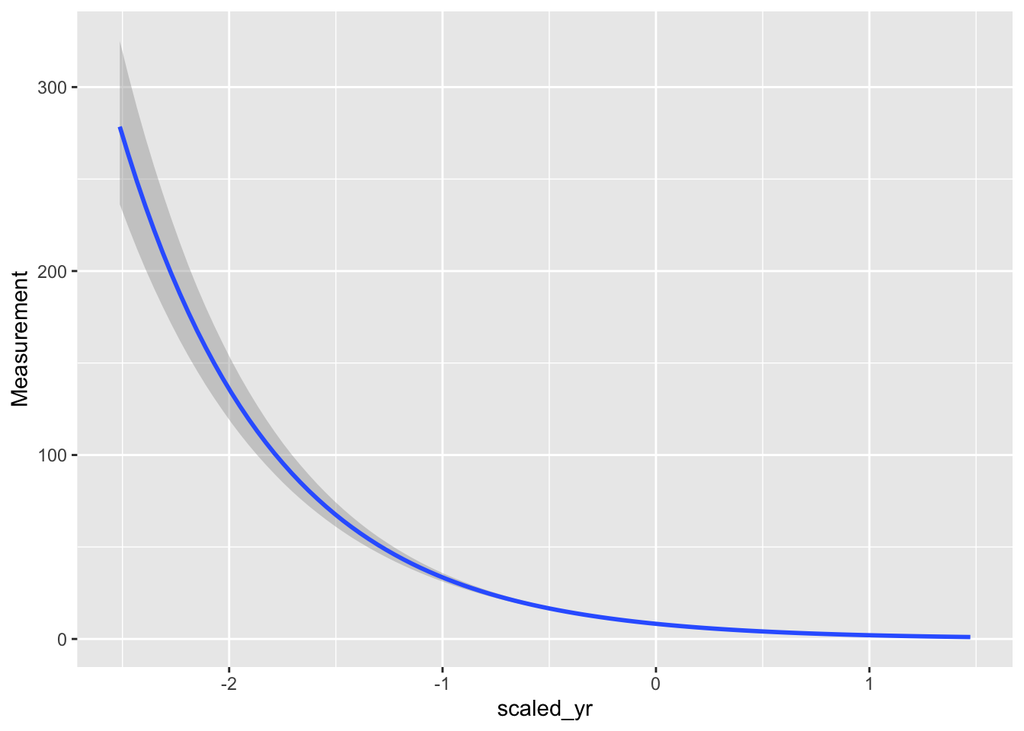

```r
plot(conditional_effects(brm_no_grass))
```

```r
pp_check(brm_no_grass)
```

```
## Using 10 posterior draws for ppc type 'dens_overlay' by default.
```

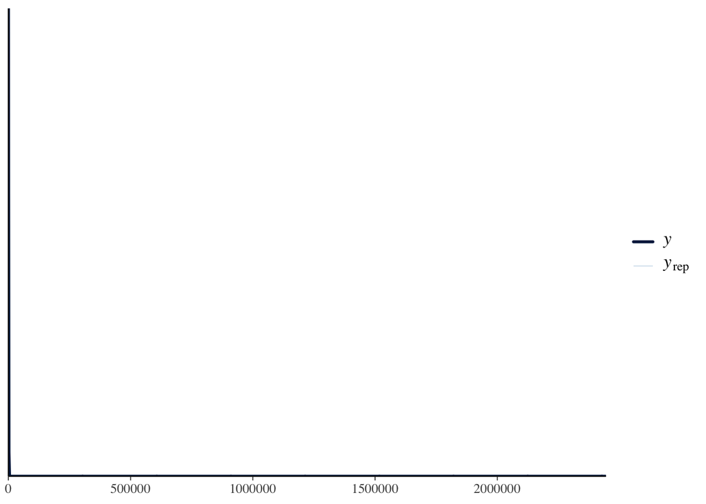

## Save arthropod estimates for manuscript inline reporting

Extracts key estimates from both models and writes `arthropod_estimates.rds` so that `index.qmd` can reference them via inline R without hardcoding numbers.

```r
load("brm_no_grass.rda")           # main:  ants included + forest biomes
load("brm_no_ants_no_grass.rda")   # sensitivity: ants excluded + forest biomes
load("dat_no_grassland.rds")

# helper: extract slope + 95% CrI + exponentiated versions from a brms fit
arth_coefs <- function(fit, dat) {
  fe   <- fixef(fit)["scaled_yr", c("Estimate", "Q2.5", "Q97.5")]
  list(
    b    = round(fe["Estimate"], 2),
    lo   = round(fe["Q2.5"],    2),
    hi   = round(fe["Q97.5"],   2),
    mult      = round(exp(fe["Estimate"]), 2),
    mult_lo   = round(exp(fe["Q2.5"]),    2),
    mult_hi   = round(exp(fe["Q97.5"]),   2),
    n    = nrow(dat)
  )
}

# ants excluded + forest biomes dataset (needed for N)
dat_no_ants_forest <- dat_no_grassland %>%
  filter(Family != "Formicidae")

arth_est <- list(
  main = arth_coefs(brm_no_grass,          dat_no_grassland),
  sens = arth_coefs(brm_no_ants_no_grass,  dat_no_ants_forest)
)

saveRDS(arth_est, file = "arthropod_estimates.rds")
message("Saved arthropod_estimates.rds — main N = ", arth_est$main$n,
        ", β = ", arth_est$main$b,
        "  |  sens N = ", arth_est$sens$n,
        ", β = ", arth_est$sens$b)
```

```
## Saved arthropod_estimates.rds — main N = 63150, β = -1.4  |  sens N = 53139, β = -1.22
```

## Sensitivity: ants-included vs ants-excluded

```r
load("brm_no_grass.rda")
load("brm_arthro_abund_no_ants.rda")

# scaled_yr slope on the log-count scale (exp = multiplicative change per SD year)
slope_main <- fixef(brm_no_grass)["scaled_yr", c("Estimate", "Q2.5", "Q97.5")]
slope_sens <- fixef(brm_no_ants)["scaled_yr",  c("Estimate", "Q2.5", "Q97.5")]

comparison <- data.frame(
  model     = c("Ants included (main)", "Ants excluded (sensitivity)"),
  log_slope = c(slope_main["Estimate"], slope_sens["Estimate"]),
  Q2.5      = c(slope_main["Q2.5"],     slope_sens["Q2.5"]),
  Q97.5     = c(slope_main["Q97.5"],    slope_sens["Q97.5"])
)
comparison$exp_slope <- exp(comparison$log_slope)
comparison$exp_Q2.5  <- exp(comparison$Q2.5)
comparison$exp_Q97.5 <- exp(comparison$Q97.5)
print(comparison)
```

```
##                         model log_slope       Q2.5     Q97.5 exp_slope
## 1        Ants included (main) -1.401006 -1.4626527 -1.341422 0.2463489
## 2 Ants excluded (sensitivity) -0.886774 -0.9521576 -0.823379 0.4119827
##    exp_Q2.5 exp_Q97.5
## 1 0.2316210 0.2614735
## 2 0.3859075 0.4389460
```

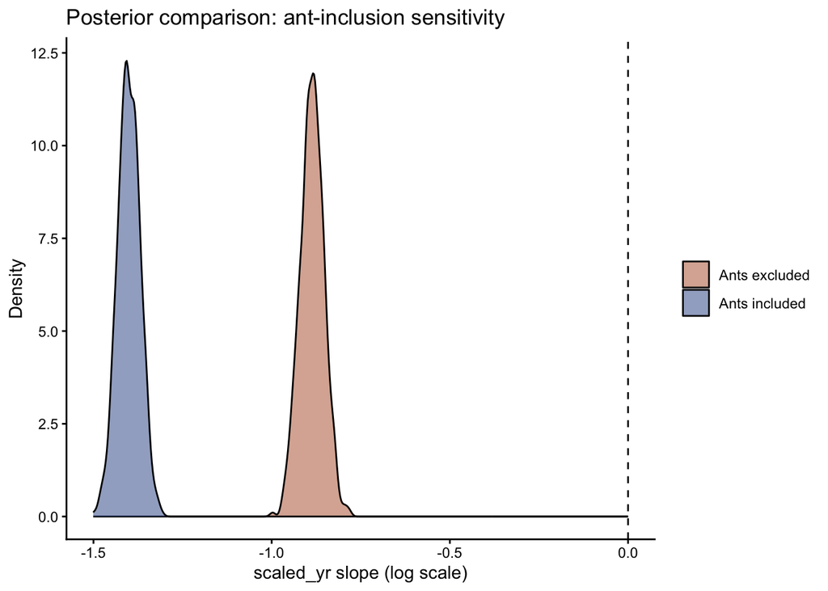

```r
# Posterior overlap: draw from both models and compare
draws_main <- as_draws_df(brm_no_grass)$b_scaled_yr
draws_sens <- as_draws_df(brm_no_ants)$b_scaled_yr

overlap_df <- data.frame(
  value = c(draws_main, draws_sens),
  model = rep(c("Ants included", "Ants excluded"), each = length(draws_main))
)

ggplot(overlap_df, aes(x = value, fill = model)) +
  geom_density(alpha = 0.5) +
  geom_vline(xintercept = 0, linetype = "dashed") +
  scale_fill_manual(values = c("Ants included" = "#2E5090", "Ants excluded" = "#B55A2E")) +
  labs(x = "scaled_yr slope (log scale)", y = "Density",
       title = "Posterior comparison: ant-inclusion sensitivity",
       fill = NULL) +
  theme_classic()
```

## Export Figure 4 (arthropod decline) for the manuscript

Saves the fitted abundance decline (forest biomes, ants included) to the manuscript’s images folder as `fig-arthropods.png`, replacing the placeholder.

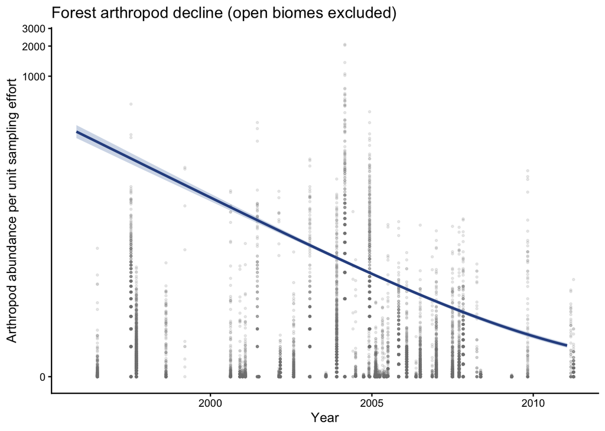

```r
load("brm_no_grass.rda")
load("dat_no_grassland.rds")

ce <- conditional_effects(brm_no_grass, effects = "scaled_yr")[[1]]
# put the x-axis back on the calendar-year scale for readability
yr_mu <- mean(dat_no_grassland$Sample_midpoint, na.rm = TRUE)
yr_sd <- sd(dat_no_grassland$Sample_midpoint,  na.rm = TRUE)
ce$year   <- ce$scaled_yr * yr_sd + yr_mu
dat_no_grassland$year <- dat_no_grassland$Sample_midpoint

fig4 <- ggplot() +
  geom_point(data = dat_no_grassland,
             aes(x = year, y = Measurement / Sampling_effort),
             alpha = 0.15, size = 0.6, colour = "grey50") +
  geom_ribbon(data = ce, aes(x = year, ymin = lower__, ymax = upper__),
              fill = "#5B7FB5", alpha = 0.3) +
  geom_line(data = ce, aes(x = year, y = estimate__), colour = "#2E5090", linewidth = 1) +
  scale_y_continuous(trans = "log1p") +
  labs(x = "Year", y = "Arthropod abundance per unit sampling effort",
       title = "Forest arthropod decline (open biomes excluded)") +
  theme_classic()

ggsave(file.path("..", "Manuscript", "images", "fig-arthropods.png"),
       fig4, width = 6.4, height = 4.4, dpi = 150)
fig4
```

> One idea I had today (Jun/24) was to use the predicted abundance of arthropods per year as a predictor in the wing length model to investigate whether bird body size is tracking temperature per se or food availability.

# References

Gardner, Janet L., Anne Peters, Michael R. Kearney, Leo Joseph, and Robert Heinsohn. 2011. “Declining Body Size: A Third Universal Response to Warming?” *Trends in Ecology & Evolution* 26 (6): 285–91. https://doi.org/10.1016/j.tree.2011.03.005.

Ozgul, Arpat, Shripad Tuljapurkar, Tim G. Benton, Josephine M. Pemberton, Tim H. Clutton-Brock, and Tim Coulson. 2009. “The Dynamics of Phenotypic Change and the Shrinking Sheep of St. Kilda.” *Science* 325 (5939): 464–67. https://doi.org/10.1126/science.1173668.

Parmesan, Camille, and Gary Yohe. 2003. “A Globally Coherent Fingerprint of Climate Change Impacts Across Natural Systems.” *Nature* 421 (6918): 37. https://doi.org/10.1038/nature01286.

Rode, Karyn D., Steven C. Amstrup, and Eric V. Regehr. 2010. “Reduced Body Size and Cub Recruitment in Polar Bears Associated with Sea Ice Decline.” *Ecological Applications* 20 (3): 768–82. https://doi.org/10.1890/08-1036.1.

Schmidt, Niels, and Per Jensen. 2005. “Concomitant Patterns in Avian and Mammalian Body Length Changes in Denmark.” *Ecology and Society* 10 (2). https://doi.org/10/gf389w.

Sheridan, Jennifer A., and David Bickford. 2011. “Shrinking Body Size as an Ecological Response to Climate Change.” *Nature Climate Change* 1 (8): 401–6. https://doi.org/10.1038/nclimate1259.

Teplitsky, Celine, and Virginie Millien. 2014. “Climate Warming and Bergmann’s Rule Through Time: Is There Any Evidence?” *Evolutionary Applications* 7 (1): 156–68. https://doi.org/10.1111/eva.12129.

Teplitsky, Céline, James A. Mills, Jussi S. Alho, John W. Yarrall, and Juha Merilä. 2008. “Bergmann’s Rule and Climate Change Revisited: Disentangling Environmental and Genetic Responses in a Wild Bird Population.” *Proceedings of the National Academy of Sciences* 105 (36): 13492–96. https://doi.org/10.1073/pnas.0800999105.

Wilman, Hamish, Jonathan Belmaker, Jennifer Simpson, Carolina de la Rosa, Marcelo M Rivadeneira, and Walter Jetz. 2014. “EltonTraits 1.0: Species-Level Foraging Attributes of the World’s Birds and Mammals: Ecological Archives E095-178.” *Ecology* 95 (7): 2027–27.

[^1]: The paper should then start with an introductory paragraph (not abstract) of no more than 200 words, summarizing the background, rationale, main results (introduced by ‘Here we show’ or some equivalent phrase) and implications of the study. This paragraph should be fully referenced. Check other guidelines to **Nature Climate Change** here: https://www.nature.com/nclimate/about/content
[^2]: I think that this paragraph is not necessary. Talk only about the ecological consequences.
[^3]: These plots are just for exploratory purposes. I can hide them later when writing the manuscript
[^4]: Glauco’s comments on July 04 2019: 1. Uni ou biparental??? 2. What is the physiological response of birds to an increase in air temperature? Should they react by reducing body size in order to dissipate heat better. 3. Estimate the heritability of wing length. Look up the average generation time for passerine birds. Estimate what is the selection differential on wing length over the period of the data. 4. I thought later about migratory status of the birds. Should I include it in the analysis?
[^5]: https://bookdown.org/ajkurz/Statistical_Rethinking_recoded/missing-data-and-other-opportunities.html